# Publika laddstationer i Dalarna

2023-06-19

Följande är en visualisering av publika laddstationer i Dalarna. Innehållet kommer att byggas på efterhand som kunskap ökar och data förändras. Data laddas ner från Nobil via en API.

**Mer information om API och definitioner**

En API är kortfattat en länk mellan två maskiner, vilket möjliggör automatiserad uppdatering av data direkt från källan.https://www.energimyndigheten.se/klimat--miljo/transporter/energieffektiva-och-fossilfria-fordon-och-transporter/laddinfrastruktur/registrera-din-laddstation/utvecklare/

Energimyndigheten definierar publik laddning som “en laddstation som står placerad där vem som helst kan ladda bilen, till exempel utmed landsvägar, i parkeringshus, vid köpcentrum, vid infartsparkeringar eller resecentrum.” https://www.energimyndigheten.se/klimat--miljo/transporter/energieffektiva-och-fossilfria-fordon-och-transporter/laddinfrastruktur/.

Anslutningspunkter och laddstationer är nyckelord; Laddstationer har olika mängd anslutningspunkter. Diagrammen nedan visar summan av anslutningspunkter och laddstationer per kommun. Malung-Sälen har flest anslutningspunkter och Smedjebacken har flest antal laddstationer.

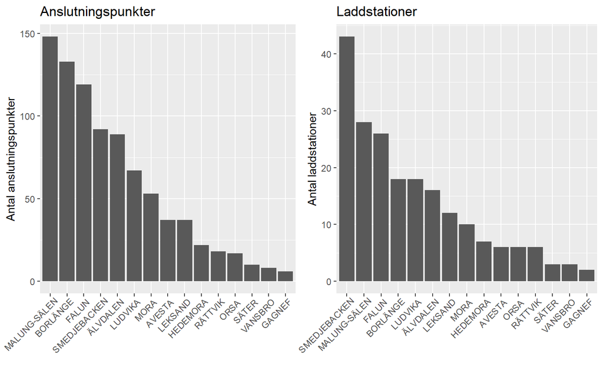

## Laddstationer och anslutningspunkter.

Kartan är interaktiv med lager som kan tändas och släckas med ikonen under zoom uppe till vänster i kartan. Det primära kartlagret är punkter på laddstationer(xy). De två andra kartlagren är aggregerad statistik på antalet anslutningspunkter respektive laddstationer på kommunnivå. Ett vänsterklick på ett objekt visar all tillgänglig information i den tabell som ligger till grund för aktuellt lager (ett vänsterklick utanför popupen i kartan stänger tabellen). När muspekaren vilar på ett objekt visas antal anslutningspunkter på aktuell laddstation eller summan av anslutningspunkter/laddstationer per kommun (beroende på vilket lager som är tänt).

[interactive chart not shown]